# UseCase_2

```python
# Importing libraries

import pandas as pd
import numpy as np
import matplotlib.pyplot as plt
import seaborn as sns
```

```python
# Load csv file

df=pd.read_csv('student_performance_data.csv')
```

```python
# Taking look at the data by Top 10 rows

df.head(10)
```

|  | StudentID | Age | Gender | SocioeconomicStatus | Grades | Attendance | TimeSpentOnHomework | ClassParticipation | AcademicPerformanceStatus |
| --- | --- | --- | --- | --- | --- | --- | --- | --- | --- |
| 0 | S0001 | 21 | Female | High | 73.821849 | 99.578045 | 3.153141 | Medium | Pass |
| 1 | S0002 | 18 | Female | Low | 61.301450 | 95.580772 | 3.160019 | Medium | Pass |
| 2 | S0003 | 19 | Female | Low | 82.023802 | 74.858691 | 1.594093 | Low | Pass |
| 3 | S0004 | 21 | Male | Low | 98.949056 | 67.806661 | 1.937389 | Medium | Pass |
| 4 | S0005 | 17 | Female | Middle | 80.174655 | 79.575701 | 1.233916 | High | Pass |
| 5 | S0006 | 19 | Male | Middle | 67.890704 | 89.665658 | 3.917964 | High | Pass |
| 6 | S0007 | 19 | Male | Middle | 82.390872 | 79.702763 | 2.759609 | Medium | Pass |
| 7 | S0008 | 21 | Male | Low | 56.146034 | 79.327235 | 3.770904 | Low | Fail |
| 8 | S0009 | 16 | Female | Middle | 94.432954 | 93.529217 | 1.561849 | Medium | Pass |
| 9 | S0010 | 17 | Male | Middle | 75.154198 | 74.456151 | 3.236618 | High | Pass |

```python
# The shape of the dataframe

df.shape
```

```
(1000, 9)
```

```python
# The index of the dataframe

df.index
```

```
RangeIndex(start=0, stop=1000, step=1)
```

```python
# The column names used

df.columns
```

```
Index(['StudentID', 'Age', 'Gender', 'SocioeconomicStatus', 'Grades',
       'Attendance', 'TimeSpentOnHomework', 'ClassParticipation',
       'AcademicPerformanceStatus'],
      dtype='object')
```

```python
# Copying the dataset into another variable, to use and make changes, by not affecting the original dataset

stud_data=df.copy()
print(stud_data)
```

```
    StudentID  Age  Gender SocioeconomicStatus     Grades  Attendance  \
0       S0001   21  Female                High  73.821849   99.578045
1       S0002   18  Female                 Low  61.301450   95.580772
2       S0003   19  Female                 Low  82.023802   74.858691
3       S0004   21    Male                 Low  98.949056   67.806661
4       S0005   17  Female              Middle  80.174655   79.575701
..        ...  ...     ...                 ...        ...         ...
995     S0996   20  Female                High  88.852464   65.525012
996     S0997   15    Male                High  93.110149   94.364470
997     S0998   21  Female              Middle  65.693775   80.002330
998     S0999   18    Male                High  76.901135   86.995728
999     S1000   20  Female              Middle  92.005404   69.562655

     TimeSpentOnHomework ClassParticipation AcademicPerformanceStatus
0               3.153141             Medium                      Pass
1               3.160019             Medium                      Pass
2               1.594093                Low                      Pass
3               1.937389             Medium                      Pass
4               1.233916               High                      Pass
..                   ...                ...                       ...
995             3.427325             Medium                      Pass
996             3.910538             Medium                      Pass
997             3.914607             Medium                      Pass
998             0.728469                Low                      Pass
999             3.376438                Low                      Pass

[1000 rows x 9 columns]
```

```python
# Assign all columns to a variable list

col=list(stud_data)
print(col)
```

```
['StudentID', 'Age', 'Gender', 'SocioeconomicStatus', 'Grades', 'Attendance', 'TimeSpentOnHomework', 'ClassParticipation', 'AcademicPerformanceStatus']
```

```python
# Taking look at the data by Top 10 rows

stud_data.head(21)
```

|  | StudentID | Age | Gender | SocioeconomicStatus | Grades | Attendance | TimeSpentOnHomework | ClassParticipation | AcademicPerformanceStatus |
| --- | --- | --- | --- | --- | --- | --- | --- | --- | --- |
| 0 | S0001 | 21 | Female | High | 73.821849 | 99.578045 | 3.153141 | Medium | Pass |
| 1 | S0002 | 18 | Female | Low | 61.301450 | 95.580772 | 3.160019 | Medium | Pass |
| 2 | S0003 | 19 | Female | Low | 82.023802 | 74.858691 | 1.594093 | Low | Pass |
| 3 | S0004 | 21 | Male | Low | 98.949056 | 67.806661 | 1.937389 | Medium | Pass |
| 4 | S0005 | 17 | Female | Middle | 80.174655 | 79.575701 | 1.233916 | High | Pass |
| 5 | S0006 | 19 | Male | Middle | 67.890704 | 89.665658 | 3.917964 | High | Pass |
| 6 | S0007 | 19 | Male | Middle | 82.390872 | 79.702763 | 2.759609 | Medium | Pass |
| 7 | S0008 | 21 | Male | Low | 56.146034 | 79.327235 | 3.770904 | Low | Fail |
| 8 | S0009 | 16 | Female | Middle | 94.432954 | 93.529217 | 1.561849 | Medium | Pass |
| 9 | S0010 | 17 | Male | Middle | 75.154198 | 74.456151 | 3.236618 | High | Pass |
| 10 | S0011 | 21 | Male | Middle | 72.467487 | 94.391787 | 3.180505 | High | Pass |
| 11 | S0012 | 17 | Female | High | 79.293239 | 76.272192 | 2.920795 | Medium | Pass |
| 12 | S0013 | 17 | Male | Low | 81.239193 | 73.129324 | 3.879736 | Low | Pass |
| 13 | S0014 | 19 | Male | Middle | 53.588790 | 78.159596 | 1.877444 | Medium | Fail |
| 14 | S0015 | 18 | Male | Middle | 84.130861 | 90.497878 | 0.957511 | Medium | Pass |
| 15 | S0016 | 17 | Male | Middle | 62.096584 | 65.040081 | 2.850981 | High | Pass |
| 16 | S0017 | 20 | Male | Middle | 85.697632 | 67.856769 | 3.052584 | Medium | Pass |
| 17 | S0018 | 19 | Male | Middle | 91.126740 | 98.057793 | 2.512712 | Medium | Pass |
| 18 | S0019 | 16 | Female | High | 90.197925 | 67.019665 | 1.223863 | Medium | Pass |
| 19 | S0020 | 18 | Male | Low | 77.625048 | 82.709093 | 2.265596 | Low | Pass |
| 20 | S0021 | 20 | Male | Low | 76.008495 | 83.172579 | 1.592664 | High | Pass |

```python
# Check null values

stud_data.isnull().sum()
```

```
StudentID                    0
Age                          0
Gender                       0
SocioeconomicStatus          0
Grades                       0
Attendance                   0
TimeSpentOnHomework          0
ClassParticipation           0
AcademicPerformanceStatus    0
dtype: int64
```

```python
# Check for duplicates

duplicates = stud_data.duplicated()
number_duplicates = duplicates.sum()
print(number_duplicates)
```

```
0
```

```python
# Display entire information of the dataframe

stud_data.info()
```

```
<class 'pandas.core.frame.DataFrame'>
RangeIndex: 1000 entries, 0 to 999
Data columns (total 9 columns):
 #   Column                     Non-Null Count  Dtype
---  ------                     --------------  -----
 0   StudentID                  1000 non-null   object
 1   Age                        1000 non-null   int64
 2   Gender                     1000 non-null   object
 3   SocioeconomicStatus        1000 non-null   object
 4   Grades                     1000 non-null   float64
 5   Attendance                 1000 non-null   float64
 6   TimeSpentOnHomework        1000 non-null   float64
 7   ClassParticipation         1000 non-null   object
 8   AcademicPerformanceStatus  1000 non-null   object
dtypes: float64(3), int64(1), object(5)
memory usage: 70.4+ KB
```

```python
# Classify the ages into Adolescents,Young Adults

def age_cat(age):
  if(age >= 15 and age <=18 ):
    return "Adolescents"
  elif(age >= 19):
    return "Young Adults"


# Add them to the dataframe

stud_data['Age_Category'] = stud_data['Age'].apply(age_cat)
```

```python
# Convert attribute sex from numerical values into categorical values

def gender(sex):
    if sex == 'Female':
      return 0
    elif sex == 'Male':
      return 1

# Add them to the dataframe

stud_data['Gender_Category'] = stud_data['Gender'].apply(gender)
```

```python
# Convert attribute target from numerical values into categorical values

def socioeconomic_status(socioeconomic):
    if socioeconomic == 'Low':
        return 0
    elif socioeconomic == 'Middle':
        return 1
    elif socioeconomic == 'High':
        return 2

# Add them to the dataframe

stud_data['Socio_Economic_Category'] = stud_data['SocioeconomicStatus'].apply(socioeconomic_status)
```

```python
# Convert attribute target from numerical values into categorical values

def academicperformance_status(academicperformance):
    if academicperformance == 'Low':
        return 0
    elif academicperformance == 'Middle':
        return 1
    elif academicperformance == 'High':
        return 2

# Add them to the dataframe

stud_data['Academic_Performance_Category'] = stud_data['AcademicPerformanceStatus'].apply(academicperformance_status)
```

```python
# Convert attribute target from numerical values into categorical values

def classParticipation(classparticipation):
    if classparticipation == 'Low':
        return 0
    elif classparticipation == 'Medium':
        return 1
    elif classparticipation == 'High':
        return 2

# Add them to the dataframe

stud_data['Class_Participation_Category'] = stud_data['ClassParticipation'].apply(classParticipation)
```

```python
# Convert numerical/categorical attributes into meaningful labels

def academicPerformance_status(aps):
    if aps == 'Fail':
        return 0
    elif aps == 'Pass':
        return 1

# Add them to the dataframe

stud_data['Academic_Performance_Category'] = stud_data['AcademicPerformanceStatus'].apply(academicPerformance_status)
```

```python
# Descriptive Statistics

stud_data.describe()
```

|  | Age | Grades | Attendance | TimeSpentOnHomework | Gender_Category | Socio_Economic_Category | Academic_Performance_Category | Class_Participation_Category |
| --- | --- | --- | --- | --- | --- | --- | --- | --- |
| count | 1000.0000 | 1000.000000 | 1000.000000 | 1000.000000 | 1000.000000 | 1000.000000 | 1000.000000 | 1000.000000 |
| mean | 17.9600 | 74.892793 | 79.448395 | 2.245859 | 0.507000 | 0.902000 | 0.806000 | 1.084000 |
| std | 2.0036 | 14.428974 | 11.417765 | 1.009563 | 0.500201 | 0.696334 | 0.395627 | 0.712356 |
| min | 15.0000 | 50.000582 | 60.001229 | 0.500795 | 0.000000 | 0.000000 | 0.000000 | 0.000000 |
| 25% | 16.0000 | 62.442623 | 69.451976 | 1.400813 | 0.000000 | 0.000000 | 1.000000 | 1.000000 |
| 50% | 18.0000 | 75.155411 | 79.329503 | 2.191778 | 1.000000 | 1.000000 | 1.000000 | 1.000000 |
| 75% | 20.0000 | 87.201111 | 89.137688 | 3.131317 | 1.000000 | 1.000000 | 1.000000 | 2.000000 |
| max | 21.0000 | 99.944631 | 99.982308 | 3.995775 | 1.000000 | 2.000000 | 1.000000 | 2.000000 |

```python
# Drop old numerical/categorical columns if no longer needed

stud_data.drop(columns=['StudentID'], inplace=True)
```

```python
# Taking look at the data by Top 10 rows

stud_data.head(10)
```

|  | Age | Gender | SocioeconomicStatus | Grades | Attendance | TimeSpentOnHomework | ClassParticipation | AcademicPerformanceStatus | Age_Category | Gender_Category | Socio_Economic_Category | Academic_Performance_Category | Class_Participation_Category |
| --- | --- | --- | --- | --- | --- | --- | --- | --- | --- | --- | --- | --- | --- |
| 0 | 21 | Female | High | 73.821849 | 99.578045 | 3.153141 | Medium | Pass | Young Adults | 0 | 2 | 1 | 1 |
| 1 | 18 | Female | Low | 61.301450 | 95.580772 | 3.160019 | Medium | Pass | Adolescents | 0 | 0 | 1 | 1 |
| 2 | 19 | Female | Low | 82.023802 | 74.858691 | 1.594093 | Low | Pass | Young Adults | 0 | 0 | 1 | 0 |
| 3 | 21 | Male | Low | 98.949056 | 67.806661 | 1.937389 | Medium | Pass | Young Adults | 1 | 0 | 1 | 1 |
| 4 | 17 | Female | Middle | 80.174655 | 79.575701 | 1.233916 | High | Pass | Adolescents | 0 | 1 | 1 | 2 |
| 5 | 19 | Male | Middle | 67.890704 | 89.665658 | 3.917964 | High | Pass | Young Adults | 1 | 1 | 1 | 2 |
| 6 | 19 | Male | Middle | 82.390872 | 79.702763 | 2.759609 | Medium | Pass | Young Adults | 1 | 1 | 1 | 1 |
| 7 | 21 | Male | Low | 56.146034 | 79.327235 | 3.770904 | Low | Fail | Young Adults | 1 | 0 | 0 | 0 |
| 8 | 16 | Female | Middle | 94.432954 | 93.529217 | 1.561849 | Medium | Pass | Adolescents | 0 | 1 | 1 | 1 |
| 9 | 17 | Male | Middle | 75.154198 | 74.456151 | 3.236618 | High | Pass | Adolescents | 1 | 1 | 1 | 2 |

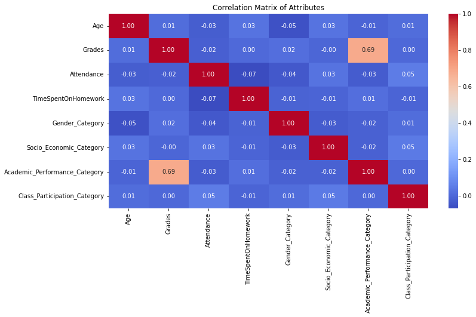

```python
# Finding correlation between attributes using heatmap

correlation_matrix = stud_data.corr(numeric_only=True)

#Plotting

plt.figure(figsize=(12,6))
sns.heatmap(correlation_matrix, annot=True, cmap='coolwarm', fmt='.2f')
plt.title("Correlation Matrix of Attributes")
plt.show()
```

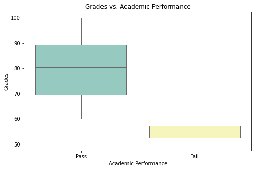

```python
# Grades vs. Academic Performance

plt.figure(figsize=(8, 5))
sns.boxplot(x='AcademicPerformanceStatus', y='Grades', hue='AcademicPerformanceStatus', data=stud_data, palette='Set3')
plt.title('Grades vs. Academic Performance')
plt.xlabel('Academic Performance')
plt.ylabel('Grades')
plt.show()
```

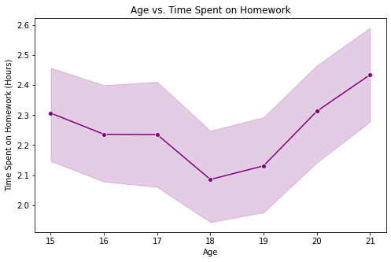

```python
#  Age vs Time Spent on homework

plt.figure(figsize=(8, 5))
sns.lineplot(x='Age', y='TimeSpentOnHomework', data=stud_data, marker='o', color='purple')
plt.title('Age vs. Time Spent on Homework')
plt.xlabel('Age')
plt.ylabel('Time Spent on Homework (Hours)')
plt.show()
```

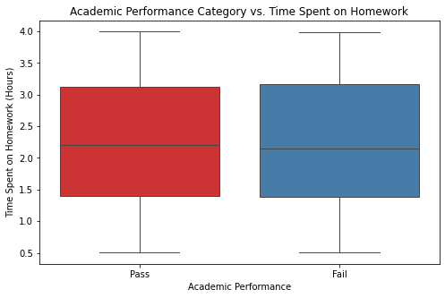

```python
#  Academic_Performance_Category vs Time Spent on homework

plt.figure(figsize=(8, 5))
sns.boxplot(x='AcademicPerformanceStatus', y='TimeSpentOnHomework', hue='AcademicPerformanceStatus',data=stud_data, palette='Set1')
plt.title('Academic Performance Category vs. Time Spent on Homework')
plt.xlabel('Academic Performance')
plt.ylabel('Time Spent on Homework (Hours)')
plt.show()
```

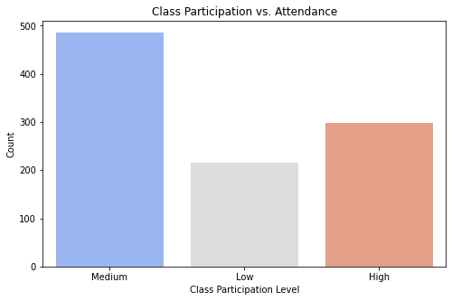

```python
# ClassParticipation vs Attendance

plt.figure(figsize=(8, 5))
sns.countplot(x='ClassParticipation', data=stud_data, hue='ClassParticipation',palette='coolwarm')
plt.title('Class Participation vs. Attendance')
plt.xlabel('Class Participation Level')
plt.ylabel('Count')
plt.show()
```

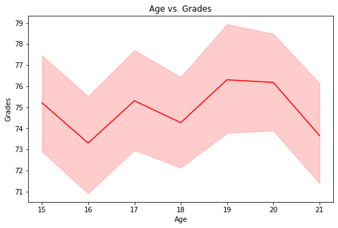

```python
# Age vs. Grades

plt.figure(figsize=(8, 5))
sns.lineplot(x='Age', y='Grades', data=df, color='red')
plt.title('Age vs. Grades')
plt.xlabel('Age')
plt.ylabel('Grades')
plt.show()
```

# Summary

The goal is to understand how factors like attendance, homework, class participation, and family background impact academic performance. By studying this, schools can take steps to help students perform better and score better grades.

# Methodology

a) The students information was cleaned by checking for null and duplicates, dropped unecessary columns and converted categorical values into numerical values using label encoding so it could be analyzed properly.

b) Calculated Mean, Median and Standard Deviation Using Descriptive Statistics.

c) To find the co-relation between the attributes used heatmap.

d) Performed Exploratory Data Analysis where visualizations were generated to analyze study the connection between grades, attendance, homework, and class participation.

# Key Findings

## Grades & Academic Performance

Students with higher grades are more likely to pass.

## Age vs Time Spent on homework

Students above the age of 20 years old spend maximum time on home works and below age of 18 years old tend to spend slightly more time on homework compared to students of age 18 and 19 years old, possibly due to stricter academic expectations.

# Recommendations

a) Encourage Regular Attendance.

b) Provide Personalized Support for Struggling Students.

c) Use Data to Identify At-Risk Students.

d) Use group discussions, interactive activities, and Q&A sessions to make classes more engaging.

e) Help Students from Low-Income Families.